# Re-Analysis of Other Published Data

Dave Bridges

September 6, 2015

This script is for the re-analysis of previously published data from other groups. This is often for presentations wherein the data was presented as a table or something and we want to draw attention to a particular aspect. This script was most recently run on Mon Sep 7 10:25:45 2015.

# Ebbeling et al JAMA 2012 Paper

The paper (Ebbeling et al. 2012) used subjects who lost 12% of their weight, then had their weight stabilized. They used a crossover design to test weight maintenance on low carbohydrate, or high carbohydrate diet. They also used a high glycemic index diet that we are ignoring here.

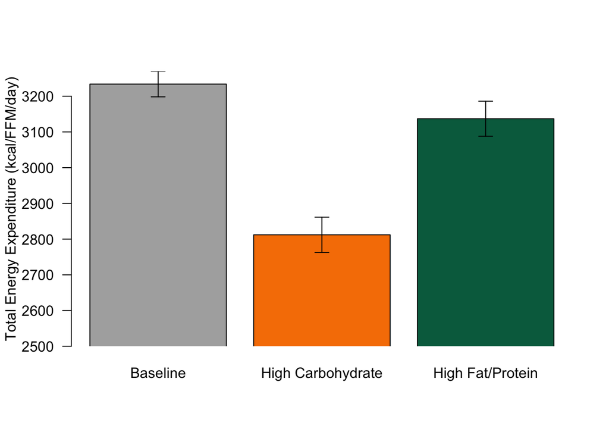

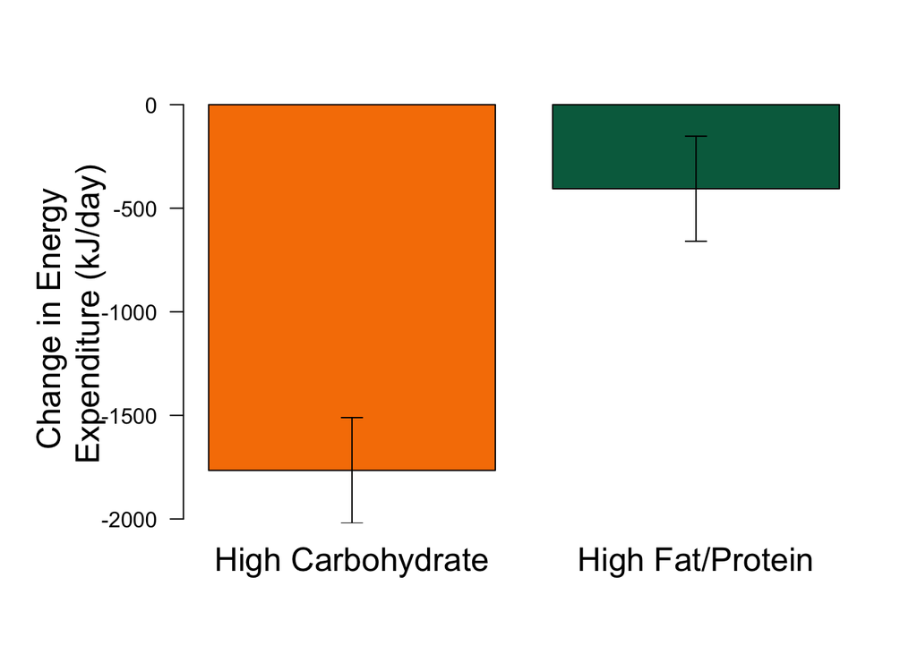

# Bray et al Overfeeding Study

In George A. Bray et al. (2012), subjects were overfed for 8 weeks with equal calories of low, normal (not included here) and high protein diet. Total energy expenditure is taken from the Table in this paper.

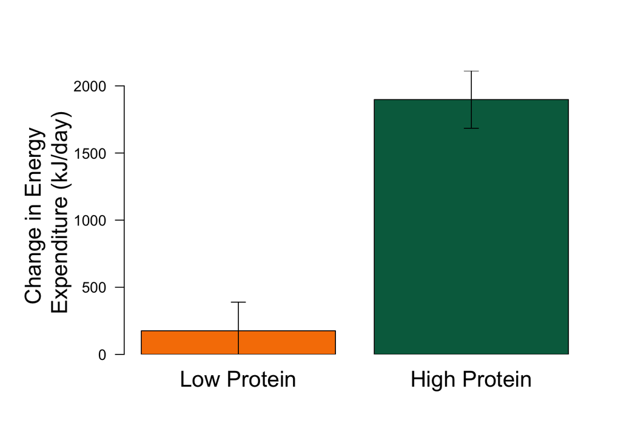

The data from the table was re-entered as Bray JAMA 2012 Table.csv.

## Bray et al Follow-Up Study

In a follow up study, G. A. Bray et al. (2015) looked at the energy expenditure in a tissue specific manner via DEXA scans.

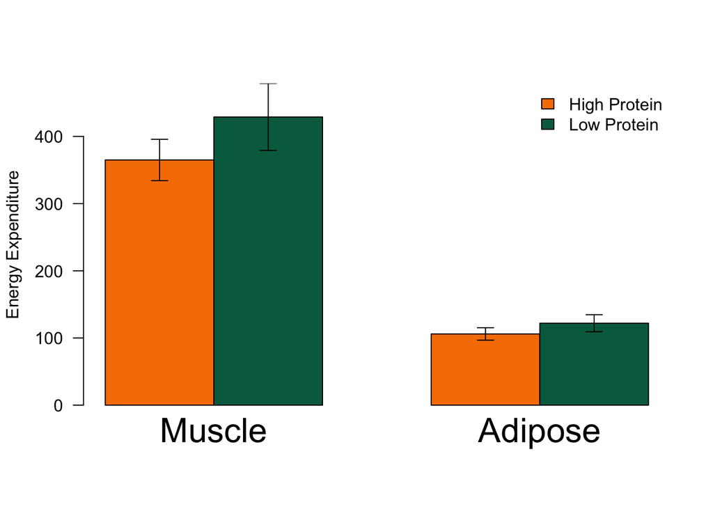

# Session Information

R version 3.2.2 (2015-08-14) Platform: x86_64-apple-darwin13.4.0 (64-bit) Running under: OS X 10.10.4 (Yosemite)

locale: [1] en_US.UTF-8/en_US.UTF-8/en_US.UTF-8/C/en_US.UTF-8/en_US.UTF-8

attached base packages: [1] stats graphics grDevices utils datasets methods base

other attached packages: [1] knitcitations_1.0.5 knitr_1.11

loaded via a namespace (and not attached): [1] Rcpp_0.12.0 lubridate_1.3.3 XML_3.98-1.3  
[4] digest_0.6.8 bitops_1.0-6 R6_2.1.1  
[7] plyr_1.8.3 formatR_1.2 magrittr_1.5  
[10] evaluate_0.7.2 httr_1.0.0 bibtex_0.4.0  
[13] stringi_0.5-5 rmarkdown_0.7 RJSONIO_1.3-0  
[16] tools_3.2.2 stringr_1.0.0 RefManageR_0.8.63 [19] RCurl_1.95-4.7 yaml_2.1.13 memoise_0.2.1  
[22] htmltools_0.2.6

Bibliography

Bray, G. A., L. M. Redman, L. de Jonge, J. Covington, J. Rood, C. Brock, S. Mancuso, C. K. Martin, and S. R. Smith. 2015. “Effect of Protein Overfeeding on Energy Expenditure Measured in a Metabolic Chamber.” *American Journal of Clinical Nutrition* 101 (3). American Society for Nutrition: 496–505. doi:10.3945/ajcn.114.091769.

Bray, George A., Steven R. Smith, Lilian de Jonge, Hui Xie, Jennifer Rood, Corby K. Martin, Marlene Most, Courtney Brock, Susan Mancuso, and Leanne M. Redman. 2012. “Effect of Dietary Protein Content on Weight Gain, Energy Expenditure, and Body Composition During Overeating.” *JAMA* 307 (1). American Medical Association (AMA): 47. doi:10.1001/jama.2011.1918.

Ebbeling, Cara B., Janis F. Swain, Henry A. Feldman, William W. Wong, David L. Hachey, Erica Garcia-Lago, and David S. Ludwig. 2012. “Effects of Dietary Composition on Energy Expenditure During Weight-Loss Maintenance.” *JAMA* 307 (24). American Medical Association (AMA). doi:10.1001/jama.2012.6607.